# Practica2

#### 2.1 Matriz de correlaciones de pearson de las variables numericas

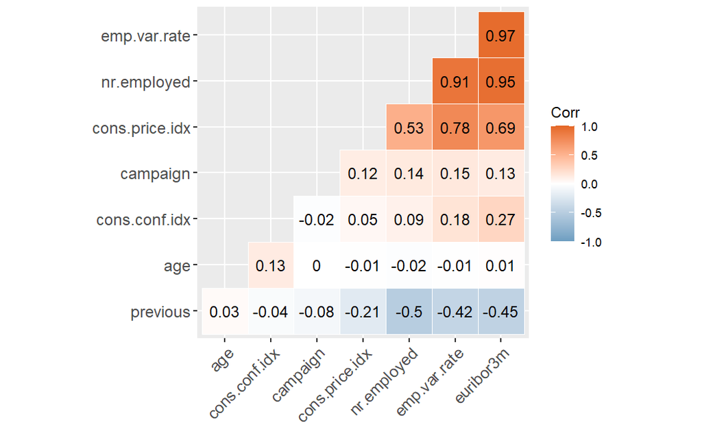

```r
corrp <- p2_train %>% select(where(is.numeric)) %>%  cor(method = 'pearson')
corrp %>% ggcorrplot(hc.order = TRUE, type = 'lower', lab=TRUE,
                      outline.col = "white",
                       ggtheme = ggplot2::theme_gray,
                       colors = c("#6D9EC1", "white", "#E46726")
                      )
```

#### 2.3 PCA

Realizamos un PCA sobre los datos para extraer los componentes principales y estudiarlos.

```r
pca <- p2_train %>% select(where(is.numeric)) %>% sample_n(200) %>%
  prcomp(scale. = TRUE, center = TRUE) #Se debe hacer un sample para posteriormente poder apreciar graficamente la distribución PCA.
summary(pca)
```

```
Importance of components:
                          PC1    PC2    PC3     PC4     PC5     PC6     PC7     PC8
Standard deviation     1.9409 1.1068 0.9735 0.89165 0.85900 0.70375 0.15192 0.09502
Proportion of Variance 0.4709 0.1531 0.1184 0.09938 0.09223 0.06191 0.00288 0.00113
Cumulative Proportion  0.4709 0.6240 0.7425 0.84184 0.93408 0.99599 0.99887 1.00000
```

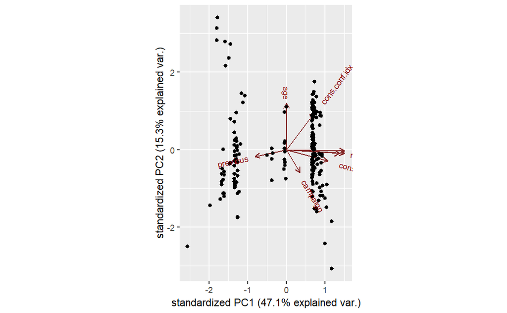

```r
pca %>%
  ggbiplot::ggbiplot(scale = 1,ellipse = T)
```

Gràfico que representa la ponderación de las variables utilizadas para el PCA.

#### 3 Grafica categorica

Para graficarlo se realiza un one hot coding del data frame para apreciar de forma adecuado la categoria “y”, ademas el codigicado de los datos categoricos a numericos con el one hot coding nos permite entrenar modelos de clasificacion que solo toman variables numericas. Hay que tener en cuenta que esta misma transformacion se debera aplicar sobre los datos de testing.

```r
onehot <- dummyVars(" ~ .", data=p2_train)
onehotdata <- data.frame(predict(onehot, newdata = p2_train))

onehotdata
```

|  | age | job.admin. | job.blue.collar | job.entrepreneur | job.housemaid | job.management | job.retired | job.self.employed | job.services | job.student | job.technician | job.unemployed | job.unknown | marital.divorced | marital.married | marital.single | marital.unknown | education.basic.4y | education.basic.6y | education.basic.9y | education.high.school | education.illiterate | education.professional.course | education.university.degree | education.unknown | default.no | default.unknown | default.yes | housing.no | … |
| --- | --- | --- | --- | --- | --- | --- | --- | --- | --- | --- | --- | --- | --- | --- | --- | --- | --- | --- | --- | --- | --- | --- | --- | --- | --- | --- | --- | --- | --- | --- |
| 1 | 52 | 0 | 0 | 0 | 0 | 0 | 0 | 0 | 0 | 0 | 1 | 0 | 0 | 0 | 1 | 0 | 0 | 0 | 0 | 0 | 1 | 0 | 0 | 0 | 0 | 1 | 0 | 0 | 0 | … |
| 2 | 33 | 1 | 0 | 0 | 0 | 0 | 0 | 0 | 0 | 0 | 0 | 0 | 0 | 0 | 0 | 1 | 0 | 0 | 0 | 0 | 0 | 0 | 0 | 1 | 0 | 1 | 0 | 0 | 0 | … |
| 3 | 54 | 1 | 0 | 0 | 0 | 0 | 0 | 0 | 0 | 0 | 0 | 0 | 0 | 0 | 0 | 1 | 0 | 0 | 0 | 0 | 0 | 0 | 0 | 1 | 0 | 1 | 0 | 0 | 0 | … |
| 4 | 53 | 0 | 0 | 0 | 1 | 0 | 0 | 0 | 0 | 0 | 0 | 0 | 0 | 0 | 1 | 0 | 0 | 0 | 0 | 0 | 1 | 0 | 0 | 0 | 0 | 1 | 0 | 0 | 1 | … |
| 5 | 42 | 0 | 0 | 0 | 0 | 0 | 0 | 1 | 0 | 0 | 0 | 0 | 0 | 0 | 1 | 0 | 0 | 0 | 0 | 0 | 0 | 0 | 0 | 1 | 0 | 0 | 1 | 0 | 0 | … |
| 6 | 36 | 0 | 0 | 0 | 0 | 1 | 0 | 0 | 0 | 0 | 0 | 0 | 0 | 0 | 1 | 0 | 0 | 0 | 0 | 0 | 0 | 0 | 0 | 1 | 0 | 1 | 0 | 0 | 1 | … |
| 7 | 40 | 0 | 0 | 0 | 0 | 0 | 0 | 0 | 0 | 0 | 1 | 0 | 0 | 1 | 0 | 0 | 0 | 0 | 0 | 0 | 0 | 0 | 0 | 1 | 0 | 1 | 0 | 0 | 0 | … |
| 8 | 44 | 0 | 1 | 0 | 0 | 0 | 0 | 0 | 0 | 0 | 0 | 0 | 0 | 0 | 0 | 1 | 0 | 1 | 0 | 0 | 0 | 0 | 0 | 0 | 0 | 1 | 0 | 0 | 0 | … |
| 9 | 36 | 0 | 0 | 0 | 0 | 0 | 0 | 0 | 0 | 0 | 1 | 0 | 0 | 1 | 0 | 0 | 0 | 0 | 0 | 0 | 0 | 0 | 1 | 0 | 0 | 1 | 0 | 0 | 1 | … |
| 10 | 48 | 0 | 0 | 0 | 0 | 1 | 0 | 0 | 0 | 0 | 0 | 0 | 0 | 0 | 1 | 0 | 0 | 0 | 0 | 0 | 0 | 0 | 0 | 1 | 0 | 1 | 0 | 0 | 1 | … |

[output cut: 990 more lines]

```r
NA
```

Partiendo de la base que la variable target es categorica, se aprecia una gran cantidad de y con no a comparacion de yes.

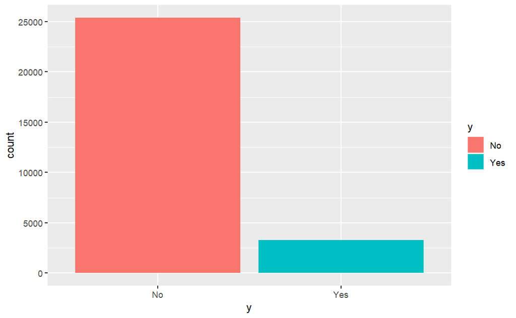

```r
ggplot(data =
    onehotdata %>%
    select(y.no, y.yes) %>%
    mutate(y = ifelse(y.no == 1, "No",
        ifelse(y.yes == 1, "Yes", "NONE"))),
    aes(x = y, fill = y)
) +
    geom_bar()
```

Se aprecia que nos encontramos ante un caso de dataset no balanceado aunque las diferencias de proporcion no son lo suficientemente grandes para causar demasiado overfiting en nuestros modelos y deberian poder generalizar bien, por este motivo, ademas de que no tenemos muchos datos, no realizaremos tecnicas de oversampling o undersampling.